# MLH1 Results Outline

**sex differences in Celegan meiosis**

Kelly, William G., Sara M. Fielder, and Rieke Kempfer. “Multiple Sex-Specific Differences in the Regulation of Meiotic Progression in C. elegans.” bioRxiv (2020).

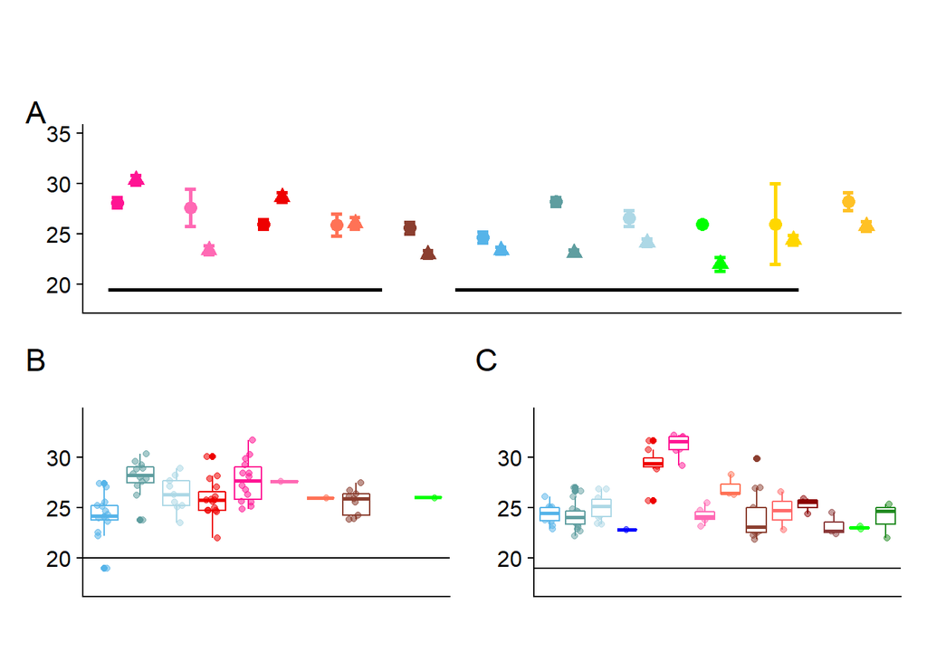

*Figure 1 Mean MLH1 count distributions by strain.* A) Strain averages of MLH1 counts per cell. B) Female specific MLH1 count distributions. C) Male specific MLH1 counts per cell.

# Genome-wide recombination rate estimates for both sexes

Graphical comparisons between the two sexes reveal several patterns (Figure 1A). First, recombination rate differs between females and males in most strains. Second, the direction and magnitude of heterochiasmy varies among strains. Although the majority of strains show higher recombination rates in females (following the pattern in laboratory mice), two musculus strains and one molossinus strain exhibit male-biased heterochiasmy. Hence, relative recombination rates in the two sexes are evolutionarily labile.

Separately examining the mouse means of MLH1 foci per cell for each sex points to distinct patterns of variation (Figure 1B-C). Female recombination rates are evenly distributed around the sex-wide mean of approximately 25 MLH1 foci per cell (Figure 1B). In stark contrast, males separate more clearly into two groups of strains with high rates (near 30 MLH1 foci per cell) and low rates (near 23 MLH1 foci per cell) (Figure 1C).

Strain Level Summary Statistics

| Subspecies | Strain | Sex | Number of Mice | Number of Cells | Mean MLH1 count per cell | cV | Var | sd | se |
| --- | --- | --- | --- | --- | --- | --- | --- | --- | --- |
| Dom | WSB | female | 14 | 184 | 25 | 15 | 13.1 | 3.6 | 0.27 |
| Dom | WSB | male | 11 | 222 | 23 | 11 | 7.2 | 2.7 | 0.18 |
| Dom | G | female | 12 | 318 | 28 | 15 | 17.5 | 4.2 | 0.24 |
| Dom | G | male | 18 | 355 | 23 | 11 | 6.9 | 2.6 | 0.14 |
| Dom | LEW | female | 9 | 147 | 27 | 18 | 23.3 | 4.8 | 0.40 |
| Dom | LEW | male | 10 | 253 | 24 | 13 | 9.6 | 3.1 | 0.20 |
| Cast | CAST | female | 1 | 1 | 26 | NA | NA | NaN | NaN |
| Cast | CAST | male | 2 | 44 | 22 | 10 | 5.2 | 2.3 | 0.34 |
| Musc | PWD | female | 15 | 222 | 26 | 14 | 14.0 | 3.7 | 0.25 |
| Musc | PWD | male | 8 | 161 | 29 | 11 | 9.8 | 3.1 | 0.25 |
| Musc | MSM | female | 14 | 300 | 28 | 16 | 19.4 | 4.4 | 0.25 |
| Musc | MSM | male | 7 | 166 | 30 | 10 | 9.7 | 3.1 | 0.24 |
| Musc | MOLF | female | 1 | 21 | 28 | 15 | 17.9 | 4.2 | 0.92 |
| Musc | MOLF | male | 6 | 119 | 23 | 11 | 6.4 | 2.5 | 0.23 |
| Musc | SKIVE | female | 1 | 32 | 26 | 12 | 9.8 | 3.1 | 0.55 |
| Musc | SKIVE | male | 3 | 86 | 26 | 10 | 7.4 | 2.7 | 0.29 |
| Musc | KAZ | female | 9 | 184 | 26 | 16 | 16.0 | 4.0 | 0.30 |
| Musc | KAZ | male | 13 | 264 | 23 | 13 | 9.2 | 3.0 | 0.19 |
| Spretus | SPRET | female | 2 | 2 | 26 | 11 | 8.0 | 2.8 | 2.00 |
| Spretus | SPRET | male | 5 | 103 | 24 | 10 | 6.2 | 2.5 | 0.25 |
| Spic | SPIC | female | 6 | 97 | 28 | 16 | 19.5 | 4.4 | 0.45 |
| Spic | SPIC | male | 4 | 133 | 26 | 11 | 7.7 | 2.8 | 0.24 |

# Partitioning variation in recombination rate

To situate variation in recombination rate within an evolutionary framework, we fit a series of models including subspecies, strain, and sex, to mean MLH1 foci counts from 187 mice. We began with a full mixed model (M1, see Methods), which showed that strain (random effect p < 10^{-6}), sex (p = 1.5510^{-8}), subspecies (p=1.7210^{-4}), and subspecies sex (p = 3.110^{-5}) each significantly affect recombination rate.

After a general linear model including all factors as fixed effects (M2) revealed only weak contributions of subspecies, we focused on additional models designed to illuminate the role of strain and sex. A general linear model with these two variables (M3) identified two strains with particularly strong effects on recombination rate: musculus<sup>MSM</sup> (p = 3.9910^{-6}) and domesticus<sup>G</sup> (p = 1.0410^{-6}). In addition, two strains exhibit strain-by-sex interactions: molossinus<sup>MSM</sup> (p = 1.2610^{-4}) and musculus<sup>PWD</sup> (p = 3.8610^{-4}).

These three strains point to rapid evolution in recombination rate in spermatocytes; we subsequently refer to them collectively as “high-recombination” strains. Analysis of the female dataset points to four strains with significant effects on recombination rate: domesticus<sup>G</sup> (p = 2.510^{-6}), molossinus<sup>MSM</sup> (p = 6.2410^{-6}), domesticus<sup>LEW</sup> (p = 0.01), and musculus<sup>PWD</sup> (p= 0.02). Strain effect sizes in females are modest in magnitude (ranging from 1 to 4 foci) compared to those in males. Together, these results demonstrate heritable differences in the genome-wide recombination rate evolving in a highly sex-specific manner over short evolutionary timescales.

# Within mouse variance in CO count per cell

Counting MLH1 foci in multiple oocytes for each female and multiple spermatocytes for each male allowed us to examine determinants of the within-mouse variance in recombination rate. To do this, we considered the same models as above, but replaced mean MLH1 foci count with within-mouse variance in MLH1 foci count per cell as the dependent variable. Sex is the only variable that significantly affects recombination rate in both the mixed model (M1) (p < 10^{-6}) and general linear models (M2) (p = 0.03) and M3 (p = 0.03).

**(sex specific results - no efficient strain effect for males. In females LEW - but this is due to cell quality difference, what about quality score and cell number within the models?**

**re-read Lenzi et al – heterogeneity in oogenesis**

# DSB. Evolution of genome-wide recombination rate is associated with evolution of double strand breaks

DMC1 measures

| category | mean MLH1 | Early Zygotene ncells | Early Zygotene mean DMC1 | Early Zygotene MLH1:DMC1 ratio | Late Zygotene ncells | Late Zygotene mean DMC1 | Late Zygotene MLH1:DMC1 ratio |
| --- | --- | --- | --- | --- | --- | --- | --- |
| WSB male | 24 | 21 | 178 | 0.14 | 20 | 144 | 0.17 |
| G male | 24 | 19 | 158 | 0.15 | 9 | 132 | 0.18 |
| KAZ male | 24 | 1 | 159 | 0.15 | 11 | 167 | 0.14 |
| PWD male | 29 | 18 | 180 | 0.16 | 18 | 141 | 0.21 |
| MSM male | 31 | 17 | 231 | 0.14 | 17 | 164 | 0.19 |

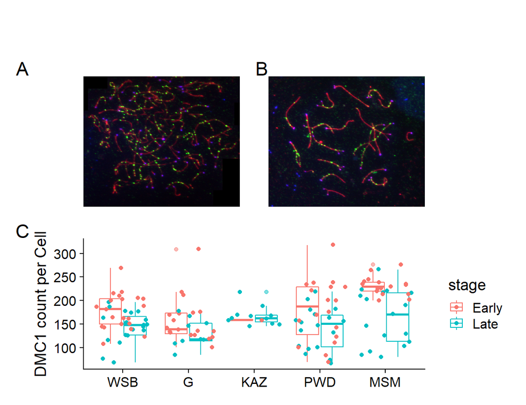

After DSB formation, DSBs are repaired as either non-crossovers (NCO) or as crossovers (COs), with the vast majority being repaired as NCOs. Thus the ratio of CO:DSB is a partial indicator of the proportion of DSBs which are designated as COs. The ratios, calculated for DMC1 means from both stages, are not significantly different between the high and low strain groups (t-test, p = 0.94 and p = 0.11 for early zygotene and late zygotene ratios, respectively). (connection to barier)

This comparison raises the possibility that the evolution of crossover number is primarily due to processes that precede the crossover/non-crossover decision. Cole et al. (2012) suggest that early zygotene counts for DMC1 are most relevant for predicting the final CO number due to the crossover homeostasis process.

# Evolution of genome-wide recombination rate is reflected at the single chromosome level

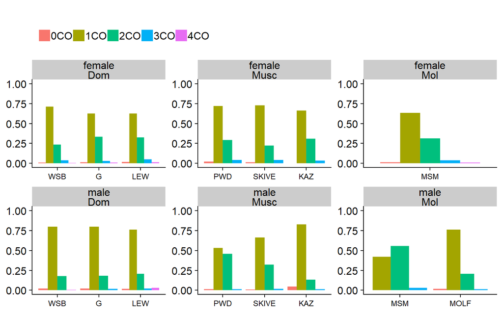

*Figure 3* Chromosome Class Proportions

To examine the connection between evolution of the genome-wide recombination rate and changes to the recombination landscape, we used an image analysis pipeline to measure properties of single bivalents ((Peterson, Miller, and Payseur 2019)).

This algorithm substantially speeds the accurate measurement of bivalents, but has the limitation that not all bivalents per cell can be isolated due to overlapping bivalents. In this dataset, isolation rates per cell range from 0.51 (molossinus<sup>MSM</sup> male) to 0.72 (musculus<sup>KAZ</sup> female).

From the total set of cell images, 10,458 bivalent objects were isolated by the image analysis software. After a human curation step ((Peterson, Miller, and Payseur 2019)), 9,829 single-bivalent observations remained. We assume that the isolation of bivalents within cells is unbiased.

Following patterns in the genome-wide recombination rate, male musculus<sup>PWD</sup> and male molossinus<sup>MSM</sup> have 2CO proportions that are more similar to each other than to strains from their own subspecies (chi-square tests; musculus<sup>PWD</sup> vs. musculus<sup>KAZ</sup> p = 3.1510^{-33}; molossinus<sup>MSM</sup> vs. molossinus<sup>MOLF</sup> p = 4.7210^{-13}).

Next, we use this single-bivalent dataset to focus on aspects of the recombination landscape along chromosomes. We address two main questions. First, which traits are sexually dimorphic? Second, which traits differ between males from high-recombination vs. low-recombination strains?

# Q1. Sex Differences in the Length of the Synaptonemal Complex

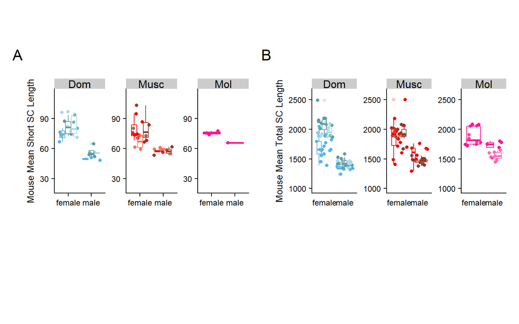

| subsp | strain | sex | nmice | ncells | mean.skel |
| --- | --- | --- | --- | --- | --- |
| Dom | WSB | female | 17 | 241 | 1684 |
| Dom | G | female | 12 | 328 | 2092 |
| Dom | LEW | female | 9 | 118 | 1969 |
| Musc | PWD | female | 18 | 207 | 1889 |
| Mol | MSM | female | 12 | 254 | 1877 |
| Musc | SKIVE | female | 1 | 37 | 1884 |
| Musc | KAZ | female | 9 | 186 | 1914 |
| Dom | WSB | male | 10 | 166 | 1344 |
| Dom | G | male | 13 | 218 | 1436 |
| Dom | LEW | male | 9 | 171 | 1427 |
| Musc | PWD | male | 8 | 116 | 1578 |
| Mol | MSM | male | 5 | 111 | 1707 |
| Mol | MOLF | male | 7 | 156 | 1552 |
| Musc | SKIVE | male | 3 | 85 | 1457 |
| Musc | KAZ | male | 13 | 256 | 1463 |
| Musc | TOM | male | 3 | 26 | 1667 |
| Musc | AST | male | 4 | 88 | 1636 |
| Musc | CZECH | male | 5 | 107 | 1573 |

In many mammalian species, the synaptonemal complex (SC) is longer in females (Cahoon and Libuda (2019), Sardell and Kirkpatrick (2020)). Yet, the majority of these observations come from species with female-biased heterochiasmy. Our wider survey of recombination in house mice provides an opportunity to determine whether sex differences in chromatin compaction (SC length) are reversed when heterochiasmy is male-biased. In addition, if SC length is a strong determinant of the genome-wide recombination rate, male musculus<sup>PWD</sup> and male molossinus<sup>MSM</sup> should have longer SC lengths than the other strains.

We use the reduce data set of short bivalents to remove the effects of the paired X-X bivalent in females. The mouse average of short bivalents are significantly longer in females than males in all strains (t-test; p < 0.05) except musculus<sup>SKIVE</sup>, which my be attributed to low sample sizes (p = 0.11). The ratios of the mouse mean SC across sexes range across strains from 1.15 (musculus<sup>MSM</sup>) to 1.49 (domesticus<sup>WSB</sup>).

Females have significantly longer total SC than males in each strain tested separately (t-test; p < 0.05). That females have longer SCs is also supported by mixed models and general linear models with covariates, which identify sex as the most consistently significant effect (p < 0.05). Additionally, there are some significant subspecies and strain effects (p < 0.05), indicating that SC length has evolved among strains and subspecies, however further investigation is beyond the scope of this paper.

In summary, two approaches for measuring and analyzing SC length indicate that females have longer SCs (chromosome axes), even in strains where males have more MLH1 foci per cell. Furthermore, joint consideration of MLH1 foci and total SC length suggests that males from high-recombination strains have less “space” in which to place their additional crossovers compared to females.

# Q1. Sex Differences in the Positions of Single Crossovers

We used the single crossover bivalent (1CO) normalized position to compared general location of crossovers while controlling for differences in total SC length. Given that, in most of the strains we surveyed, the majority of bivalents are observed to contain one crossover (focus) – thus justifying the use of single crossover bivalents – to discribe this metric / trait.

In all strains, the landscape across 1CO bivalents is significantly different in females and males. Normalized foci positions tend to be more central in females 0.56 and closer to the telomere in males 0.68 (t-test; p = 2.9210^{-22}).

Sex is also the most significant effect on focus position in a mixed model (M1: p = 1.2610^{-25}) and in general linear models (M2: p = 1.3310^{-7}; M3: p = 1.3310^{-7}). These sex differences in the placement of foci on 1CO bivalents follow a pattern observed across a variety of mammalian species (Sardell and Kirkpatrick 2020).

# Q1. Sex Differences in CO Interference (IFD)

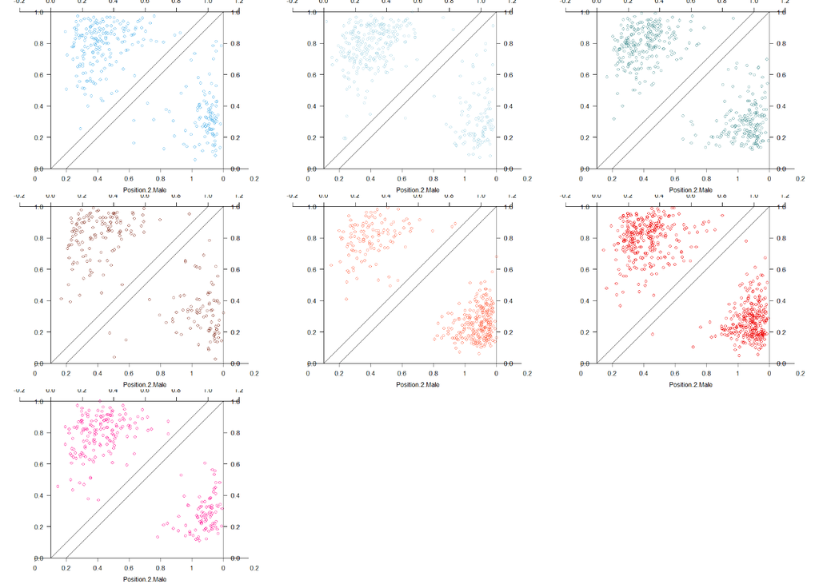

Distribution of normalized foci positions (IFDs) for double crossover bivalents across sexes. Female and male patterns are displayed in the top and bottom triangle respectively. Each point reflects a single double crossover bivalent, with the normalized positions of foci reflected on each axis.

**address the difference is pattern signal for IFD triangles and boxplots** (make boxplots?)

# Additional Determinants of Genome-wide Recombination Rate Evolution in Males

Next, we used the contrast between males in the high-recombination strains (musculus<sup>PWD</sup> , musculus<sup>SKIVE</sup>, and molossinus<sup>MSM</sup>) and low-recombination strains to identify features of the recombination landscape associated with evolutionary transitions in the genome-wide recombination rate. The main objective of this section is to test for significant correlations between features of the recombination landscape and the evolution of mean MLH1 foci per cell. In comparing the male specific single bivalent based metrics the first criteria for analysis is a significant differences between the high and low recombining groups and the second step is testing for significant subspecies and strain effects (M4 and M4.2).

Previous empirical work suggests basic predictions for the relationship between the genome wide recombination rate and two aspects of the recombination landscape. **SC length is expected to be positively associated with genome-wide recombination rate because of the loop-axis structure** (zickler Kleckner 1999, Merier 2015?). Crossover interference strength is expected to be negatively associated with genome-wide recombination rate as interference strength is reflected as the space between crossovers on the same chromosome (on chromosomes of a finite length, increasing interference strength can result in ‘pushing’ additional crossovers off of the chromosomes.

Following this logic we predict (1) musculus<sup>PWD</sup> will have greater SC length and weaker interference than musculus<sup>SKIVE</sup>, which in turn will have longer SC and weaker interference compared to the other *musculus* strains, (2) molossinus<sup>MSM</sup> will have longer SC and weaker interference compared to molossinus<sup>MOLF</sup>, and 3) *domesticus* strains will have similar SC length and crossover interference.

# Q2 SC Length

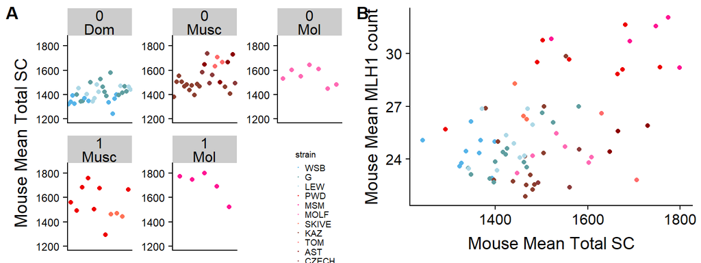

While high-recombination strains have significantly greater mouse mean total SC area in the total dataset (t-test; p = 0.01), separate tests by strain show that only within *molossinus* are high- and low-recombination strains significantly different (t-test; molossinus: p = 0.03; musculus: p = 0.87). **the values above are diferent between editions**

Additionally, the mouse means for the reduced (short and long) bivalent datasets are not significantly different between high-recombination and low-recombination strains (t-test; short: p = 0.88; long: p = 0.18).

**the values between versions are slightly different** In a general linear model with total SC as the dependent variable, two subspecies effects are significant (p = musculus 1.2410^{-6}, molossinus p = 10^{-6}). In general linear models with reduced bivalent means as dependent variables, several subspecies and strain effects reach significance (p < 0.05) but they are not consistent across models, indicating to some extent the chromatin compaction evolution is decoupled from evolution in mean MLH1 foci per cell. **Bret’s comment; How can you differentiate between this biological conclusion and uncertainty due to the size of the datasets and statistical approaches?**

# Q2.1CO rec landscape evolution is decoupled from gwRR evolution

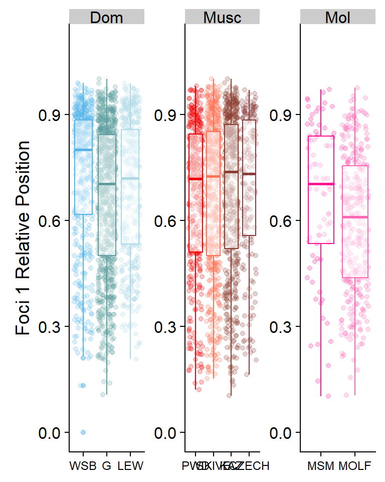

Male distributions of single crossover normalized positions.

# Q2 Evolution of interference is associated with genome wide recombination rate evolution

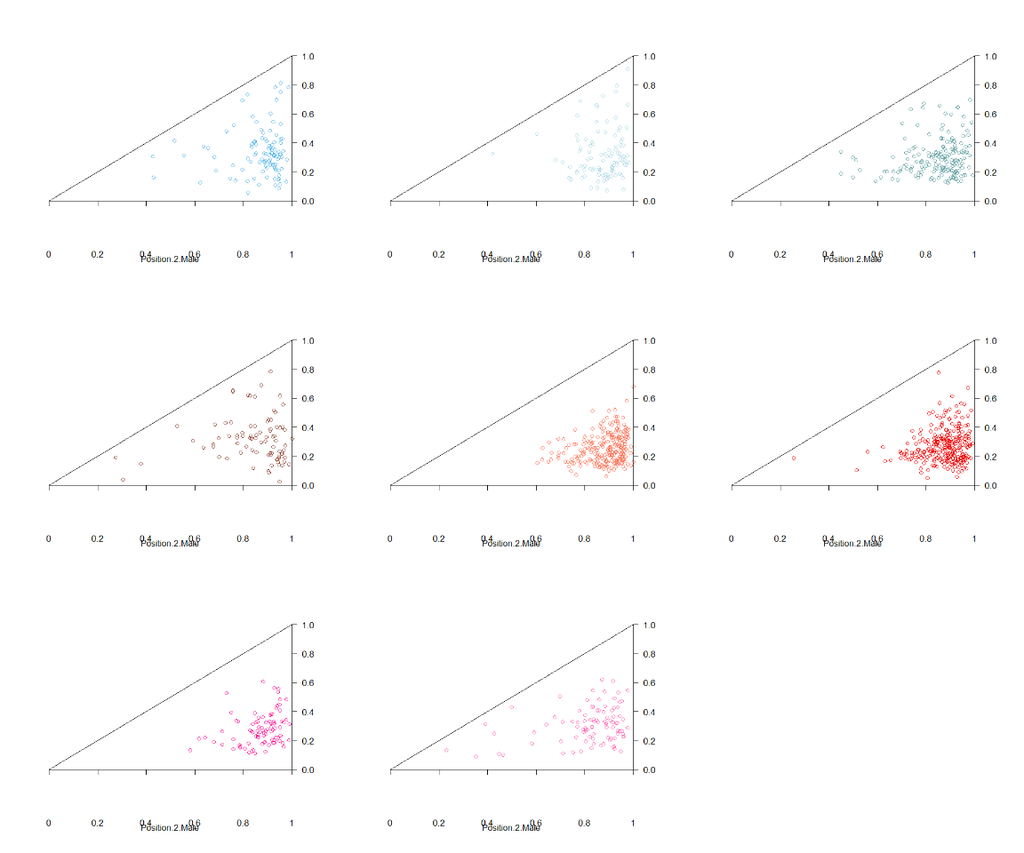

male IFD distributions highlighting differences across recombining groups

That IFD<sup>raw</sup> and IFD<sup>norm</sup> show similar patterns eliminates variation in SC lengths and bivalent sizes as primary explanations. We determined that the main difference in IFD<sup>norm</sup> distributions between high-recombination and low-recombination strains is an enrichment of IFD<sup>norm</sup> values under 30% in low-recombination strains. The frequency of IFD<sup>norm</sup> values that fall below 30% ranges from 8.2% (domesticus<sup>G</sup>) to 16% (musculus<sup>KAZ</sup>) in low-recombination strains, whereas high-recombination strains all show such frequencies below 5% (0%, 1.3%, and 3.3% for musculus<sup>SKIVE</sup>, molossinus<sup>MSM</sup>, and musculus<sup>PWD</sup>, respectively).

In summary, the level of interference is a significant predictor of evolution in the genome-wide recombination rate, but SC length and crossover position on 1CO bivalents are not. However, the pattern is in the opposite direction to our prediction: high-recombination strains have stronger interference.

# References

Cahoon, Cori K, and Diana E Libuda. 2019. “Leagues of Their Own: Sexually Dimorphic Features of Meiotic Prophase I.” *Chromosoma*. Springer, 1–16.

Cole, Francesca, Liisa Kauppi, Julian Lange, Ignasi Roig, Raymond Wang, Scott Keeney, and Maria Jasin. 2012. “Homeostatic Control of Recombination Is Implemented Progressively in Mouse Meiosis.” *Nature Cell Biology* 14 (4). Nature Publishing Group: 424–30.

Peterson, April L, Nathan D Miller, and Bret A Payseur. 2019. “Conservation of the Genome-Wide Recombination Rate in White-Footed Mice.” *Heredity* 123 (4). Nature Publishing Group: 442–57.

Sardell, Jason M., and Mark Kirkpatrick. 2020. “Sex Differences in the Recombination Landscape.” *The American Naturalist* 195 (2): 361–79. doi:10.1086/704943.